# Psychologie (augustový turnus)

Zpět na rozcestník zpětné vazby | Tento report we Wordu | Data v CSV

## Hodnocení kurzu

Průměrná známka:

| Blok setkání | Průměrná známka |
| --- | --- |
| A | 1.10 |
| B | 1.52 |
| oba | 1.30 |

### Hodnocení po dnech

A a B jsou bloky (A je 9-10:30, B je 11-12:30)

Známky jsou jako ve škole: 1 je nejlepší, 5 nejhorší

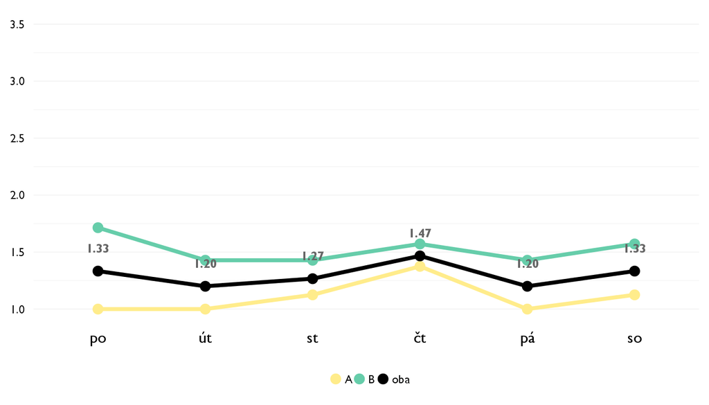

### Co se na kurzu líbilo

- Eliska! Je skvela, pozitivni a chapajici. Psychologie byla supr. Nejlepsi bylo asi Eliscino povidani o druzich lasky o syndomu tyrane zeny .. Wow to me vazne bavilo.
- Nově naučené informace a možnost diskutovat s ostatními o jejich názorech.
- komunikácia, autentické vysvetlovanie
- Vsetko
- Pacila sa mi otvorenost Elisky a aj clenov kurzu.
- Úplne všetko bolo super. Najviac sa mi páčilo, že to bolo v takej forme aby som to mohla používať v živote.
- diskusie, videa a osobnostny profil.
- ze to bol odostatocne volne a mohli sme kazdy vyjadrit svoj nazor. Nebolo to vobec nudne a bavili sme sa o temach, ktoré nas zaujimali
- Vše se mi líbilo.
- Nejvíc se mi líbil Eliščin přístup. Nechala nás diskutovat, učila nás, uváděla příklady i historky ze života a rady do něj :)
- Originalita a poutavost
- Roznorodost aktualnych tem a to že som sa na psychologiu zacala pozerat inac - bez predsudkov
- Nejednalo se ciste o prednasky, hrozne se mi libily skupinove diskuse. Eliska byla skvela ucitelka a hrozne moc jsem se toho naucila.
- naucila sa vela veci o sebe
- vysvetlenia a praktické rady k riešeniu konfliktov, problémov so sústredením, a vzťahov. super bolo cvičebie s mapovaním emócii, nikdý ma vedome nenapadlo rozmýšľať o tom tak. Veľmi dobrý bol aj rozbor zmeny

### Co na kurzu změnit

- No, vice bych ridila diskuze, ktere se casto tahly ne uplne nadejnym smerem. Jako fajn, ale nekteri lidi sami nepoznaji, kdy prestat a potrebuji trosku usmernit.
- Možná více moderovat diskuze :)
- nič
- Nic
- Mne to takto vyhovovalo.
- nic ma nenapada. kurz som si nesmierne uzil.
- Možná bych šla v určitých věcech víc do hloubky, ale to se dalo po kurzu, ve voném čase
- …
- asi nic
- spravte nejaký experiment. experimenty sú cool

## Hodnocení lektora

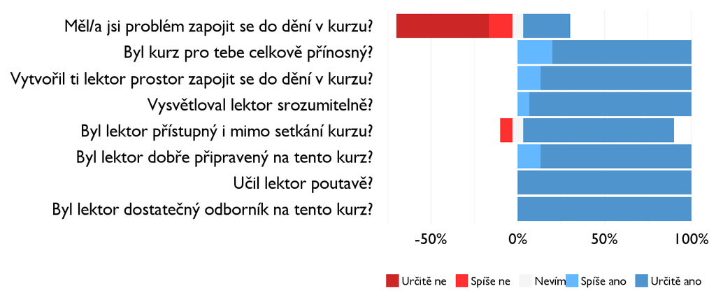

### Komentáře k lektorovi

- Elisko, ukazovani lidskeho premysleni na aktivitach je super. Myslim tim, ty zmeny… Zmen na sobe 10 veci a tak. Bezvadna technika. Mozna bych spis dala vic techto nez diskuzi.
- Děkuju za všechno Eliško :)
- eliška bola super
- Eliška je super
- Děkuji, Eliško!<3
- Eliška učila výborně. Hodiny byly dokonálé a nejraděli bych je měla dopoledne i odpoledne :)
- Eliška bola super! Pacilo sa mi na nej aka bola ludska a chapava
- Fakt jeste jednou dekuju za to, jakym zpusobem jsi k nam pristupovala Elisko.
- bolo to všetko tak milo pozitívne a nenútené

## Náročnost kurzu

### **Jak hodnotíš náročnost…**

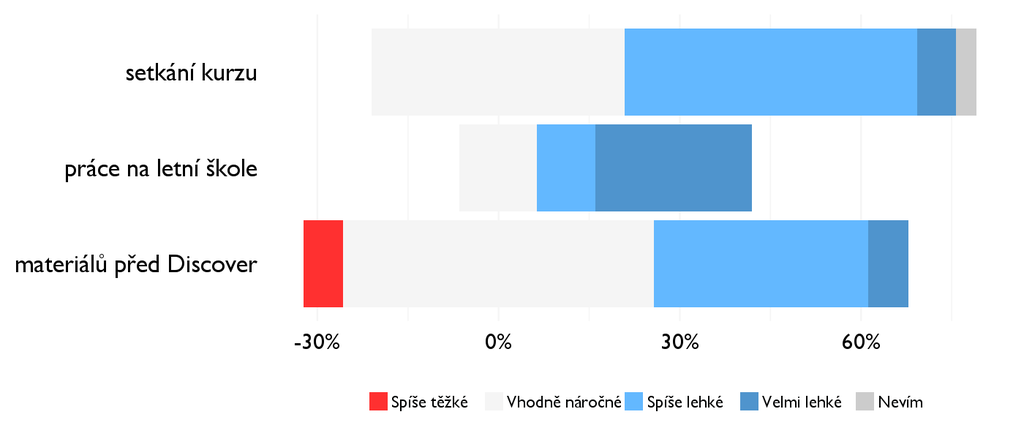

## Didaktika

Na některé otázky jsme se na augustovém turnuse neptali - tam uvidíte nadpis bez grafu.

### Jak lektor učí a měl by to změnit?

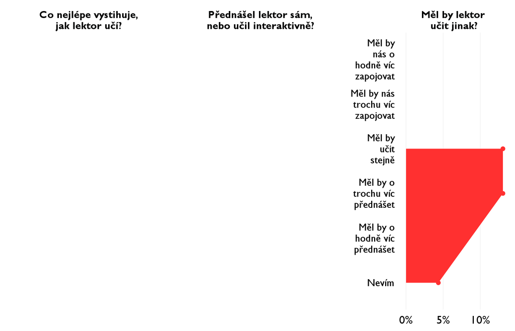

### Jak se studentům nejlépe učí?

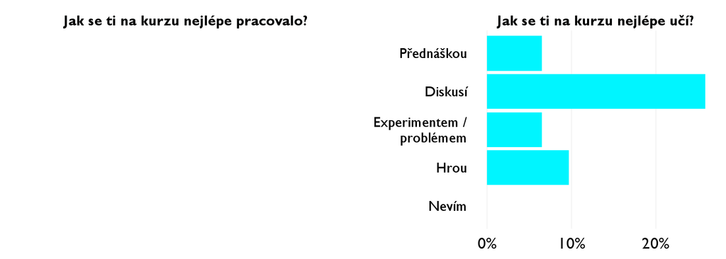

## Ovlivnil tě kurz nějak?

**Pokud ano, jak? Pokud ne, proč ne?**

- Hodne me bavilo probirani experimentu a eliscino povidani, ktereho si myslim, ze bylo zbytecne malo a casto jsem spis poslouchala opakujici se nazory nekterych lidi.
- Ano, zvažuji psychologii jako něco čemu bych se mohla více věnovat.
- Naučil ma byt vnímavý svojich implicitných postojov
- Dozvěděla som se vela o sebe a lepší som pochopil ako funguje mezilidské vztahy a na o si mám dát pozor
- Dokazem sa inak pozerat na problemy a viem na com mam do buducna pracovat :)
- Ano. Naučila som sa veľa vecí, ktoré budem určite využívať.
- vo vnimani sveta, rieseni problemov a vo venovani pozornosti detailom a ine rozne uzitocne techniky
- na niektore veci sa uz pozeram inak a snazim sa viac si vsimat ludi okolo a premyslat nad nimi
- ANo, kurz mě usvědčil v tom, že ybch se v budoucnosti chtěla věnovat psychologii naplno-
- Ano, vela v myšlení a pohledu na radost, štěstí, lidský život /)
- Nový náhled a všední issues.
- Ano - upresnila som si ake je pre mna idealne fungovanie muza a zeny vo vztahu, navstevovat psychologa je ok, viac zit pre okamih
- Rozhodne v nahledu na moji budoucnost. Hrozne moc si toho cenim.
- urcite budem citat knihy v tej tematike
- v roymýšľaní o ľuďoch a osobnostnom rozvoji, dúfam